# MSDS Second Case Study

Alec Lepe, Che Cobb

11/28/2018

### Load Libraries

```r
#install.packages("data.table")
#install.packages("readxl")
#install.packages("ggplot2")
#install.packages("reshape")
#install.packages("pander")
library("pander")
library("data.table")
library("readxl")
library("ggplot2")
library("reshape")
```

### Load Data

```r
casedata=data.table::as.data.table(readxl::read_excel("Data/CaseStudy2-data.xlsx"))
save(casedata,file="Data/CaseStudy2-data.RData")
load("Data/CaseStudy2-data.RData")
dim(casedata)
```

```
## [1] 1470   35
```

```r
str(casedata)
```

```
## Classes 'data.table' and 'data.frame':   1470 obs. of  35 variables:
##  $ Age                     : num  41 49 37 33 27 32 59 30 38 36 ...
##  $ Attrition               : chr  "Yes" "No" "Yes" "No" ...
##  $ BusinessTravel          : chr  "Travel_Rarely" "Travel_Frequently" "Travel_Rarely" "Travel_Frequently" ...
##  $ DailyRate               : num  1102 279 1373 1392 591 ...
##  $ Department              : chr  "Sales" "Research & Development" "Research & Development" "Research & Development" ...
##  $ DistanceFromHome        : num  1 8 2 3 2 2 3 24 23 27 ...
##  $ Education               : num  2 1 2 4 1 2 3 1 3 3 ...
##  $ EducationField          : chr  "Life Sciences" "Life Sciences" "Other" "Life Sciences" ...
##  $ EmployeeCount           : num  1 1 1 1 1 1 1 1 1 1 ...
##  $ EmployeeNumber          : num  1 2 4 5 7 8 10 11 12 13 ...
##  $ EnvironmentSatisfaction : num  2 3 4 4 1 4 3 4 4 3 ...
##  $ Gender                  : chr  "Female" "Male" "Male" "Female" ...
##  $ HourlyRate              : num  94 61 92 56 40 79 81 67 44 94 ...
##  $ JobInvolvement          : num  3 2 2 3 3 3 4 3 2 3 ...
```

[output cut: 22 more lines]

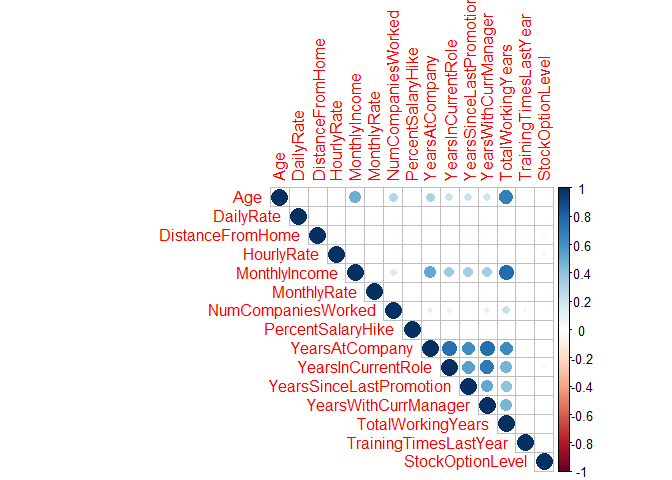

```r
library(corrplot)
library(magrittr)
numeric=casedata %>% dplyr::select(Age,DailyRate,DistanceFromHome,HourlyRate,MonthlyIncome,MonthlyRate,NumCompaniesWorked,PercentSalaryHike,YearsAtCompany,YearsInCurrentRole,YearsSinceLastPromotion,YearsWithCurrManager,TotalWorkingYears,TrainingTimesLastYear,StockOptionLevel)
corrplot(cor(numeric),method="circle",type="upper")
```

### Detect and Delete Non-Relevant Data

```r
cns=c()
for (cn in colnames(casedata)){
  if(length(table(casedata[[cn]]))==1){
    print(cn)
    cns=append(cn,cns)
  }
}
```

```
## [1] "EmployeeCount"
## [1] "Over18"
## [1] "StandardHours"
```

```r
for (cn in cns){
  print(paste(cn,names(table(casedata[[cn]])),table(casedata[[cn]])))
  casedata=casedata[,!cn,with=F]
}
```

```
## [1] "StandardHours 80 1470"
## [1] "Over18 Y 1470"
## [1] "EmployeeCount 1 1470"
```

Deleted: *Standard Hours*, *Over18*, and *EmplyoeeCount* where there is only one value.

```r
library(dplyr)
```

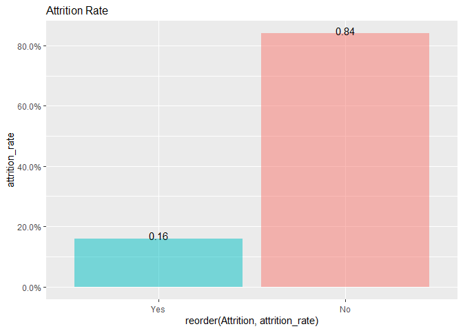

```r
library(scales)
casedata %>%group_by(Attrition)%>%summarize(attrition_count=n())%>%ungroup()%>%
  mutate(attrition_rate=round(attrition_count/sum(attrition_count),2))%>%ggplot(aes(x=reorder(Attrition,attrition_rate),y=attrition_rate,fill=Attrition)) + geom_bar(stat='identity',alpha=0.5) +
   theme(axis.text.x=element_text(angle=0,vjust=0.5),legend.position='none',plot.title = element_text(size=12))+labs(title="Attrition Rate")+scale_y_continuous(labels=percent_format())+geom_text(aes(label=attrition_rate),vjust=0.1)
```

### How does age relate to attrition?

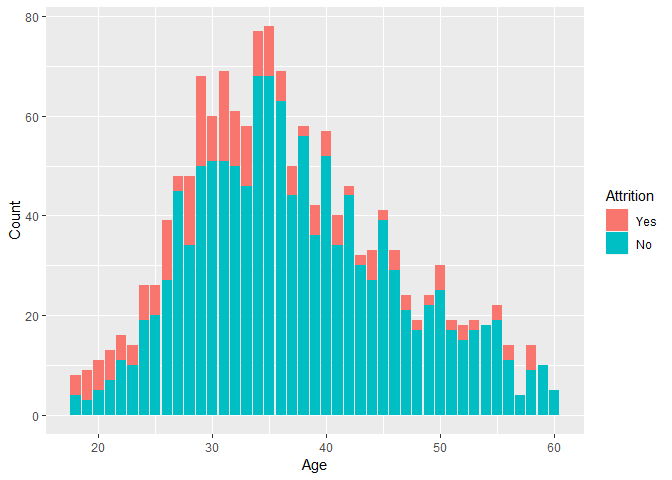

```r
ID="Age"
yes=casedata[,sum(Attrition=="Yes"),ID]; colnames(yes)[2]="Yes"
no=casedata[,sum(Attrition=="No"),ID];   colnames(no)[2]="No"
temp=merge(yes,no,all=T)
temp=melt(temp,id=ID)
temp=as.data.frame(temp)
colnames(temp)=c(ID,"Attrition","Count")
ggplot(temp,aes(fill=Attrition,y=Count,x=eval(as.symbol(ID))))+geom_bar(stat="identity")+xlab(ID)
```

Here we can see that attrition is greatest between 28 and 35.

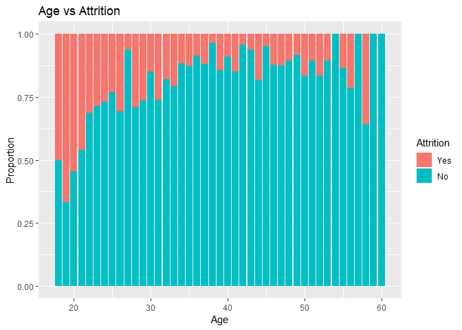

```r
temp=merge(temp,as.data.table(temp)[,sum(Count),ID])
colnames(temp)[ncol(temp)]="Total"
temp[["Proportion"]]=temp[["Count"]]/temp[["Total"]]
ggplot(temp,aes(fill=Attrition,y=Proportion,x=eval(as.symbol(ID))))+geom_bar(stat="identity")+xlab(ID)+ggtitle(paste(ID,"vs Attrition"))
```

Here we see that attrition is greater at earlier ages, with a noticeable peak at age 58.

```r
temp[temp[["Age"]]==58,]
```

```
##    Age Attrition Count Total Proportion
## 81  58       Yes     5    14  0.3571429
## 82  58        No     9    14  0.6428571
```

### How does business travel relate to attrition?

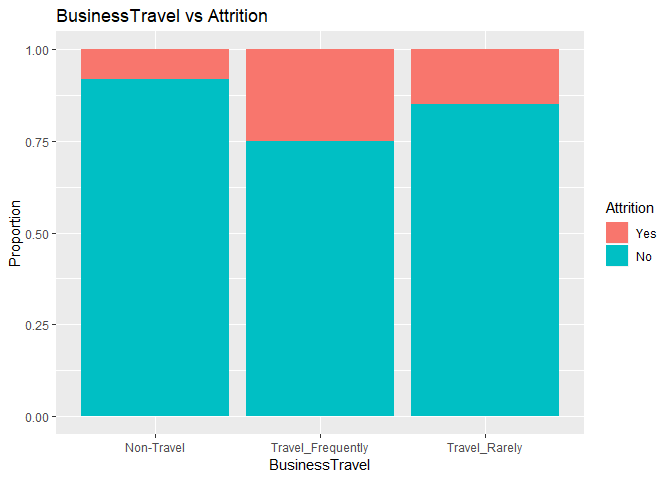

```r
ID="BusinessTravel"
yes=casedata[,sum(Attrition=="Yes"),ID]; colnames(yes)[2]="Yes"
no=casedata[,sum(Attrition=="No"),ID];   colnames(no)[2]="No"
temp=merge(yes,no,all=T)
temp=melt(temp,id=ID)
temp=as.data.frame(temp)
colnames(temp)=c(ID,"Attrition","Count")
temp=merge(temp,as.data.table(temp)[,sum(Count),ID])
colnames(temp)[ncol(temp)]="Total"
temp[["Proportion"]]=temp[["Count"]]/temp[["Total"]]
ggplot(temp,aes(fill=Attrition,y=Proportion,x=eval(as.symbol(ID))))+geom_bar(stat="identity")+xlab(ID)+ggtitle(paste(ID,"vs Attrition"))
```

Here we can see that attrition, proportionally, is greatest for employees who travel frequently and the least for employees who do not travel.

### Automatically Detecting Good Single Predictors

We can go on and on plotting individual predictors, but let’s try to automate the process. This R code will go through every numeric variable and see if they can predict attrition.

```r
tempcasedata=casedata
tempcasedata[tempcasedata[["Attrition"]]=="Yes",][["Attrition"]]="1"
tempcasedata[tempcasedata[["Attrition"]]=="No",][["Attrition"]]="0"
mode(tempcasedata[["Attrition"]])="numeric"
pmatrix=matrix(ncol=2,nrow=0)
for (i in setdiff(colnames(tempcasedata),"Attrition")){
  if (mode(tempcasedata[[i]])=='numeric'){
  formula=paste0("Attrition~",i,sep="")
  model=lm(formula,tempcasedata)
  pmatrix=rbind(pmatrix,c(i,summary(model)$coefficients[8]))
}
}
pmatrix=as.data.table(pmatrix[order(as.numeric(pmatrix[,2])),])
colnames(pmatrix)=c("Variable","P-Value")
```

Here are the top 6 variables, based on low P-Values.

```r
head(pmatrix)
```

```
##                Variable              P-Value
## 1:    TotalWorkingYears 4.06187811126712e-11
## 2:             JobLevel 6.79538478002213e-11
## 3:   YearsInCurrentRole  6.0031858436432e-10
## 4:        MonthlyIncome 7.14736398535422e-10
## 5:                  Age  8.3563080211039e-10
## 6: YearsWithCurrManager 1.73698678452455e-09
```

```r
cat(head(pmatrix)[["Variable"]])
```

```
## TotalWorkingYears JobLevel YearsInCurrentRole MonthlyIncome Age YearsWithCurrManager
```

### Plotting Statistically Significant Data

Excluding age as we previouslyu plotted that out.

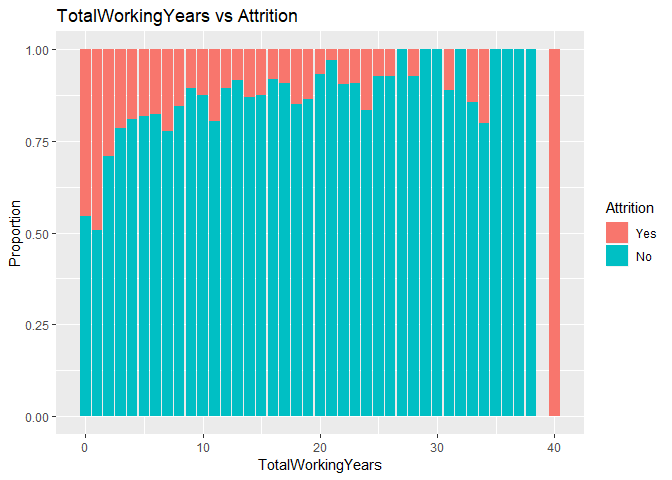

```r
ID="TotalWorkingYears"
yes=casedata[,sum(Attrition=="Yes"),ID]; colnames(yes)[2]="Yes"
no=casedata[,sum(Attrition=="No"),ID];   colnames(no)[2]="No"
temp=merge(yes,no,all=T)
temp=melt(temp,id=ID)
temp=as.data.frame(temp)
colnames(temp)=c(ID,"Attrition","Count")
temp=merge(temp,as.data.table(temp)[,sum(Count),ID])
colnames(temp)[ncol(temp)]="Total"
temp[["Proportion"]]=temp[["Count"]]/temp[["Total"]]
ggplot(temp,aes(fill=Attrition,y=Proportion,x=eval(as.symbol(ID))))+geom_bar(stat="identity")+xlab(ID)+ggtitle(paste(ID,"vs Attrition"))
```

```r
temp[temp[["TotalWorkingYears"]]==40,]
```

```
##    TotalWorkingYears Attrition Count Total Proportion
## 79                40       Yes     2     2          1
## 80                40        No     0     2          0
```

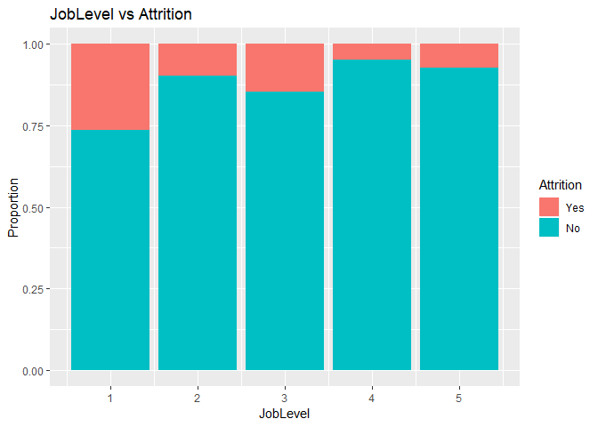

```r
ID="JobLevel"
yes=casedata[,sum(Attrition=="Yes"),ID]; colnames(yes)[2]="Yes"
no=casedata[,sum(Attrition=="No"),ID];   colnames(no)[2]="No"
temp=merge(yes,no,all=T)
temp=melt(temp,id=ID)
temp=as.data.frame(temp)
colnames(temp)=c(ID,"Attrition","Count")
temp=merge(temp,as.data.table(temp)[,sum(Count),ID])
colnames(temp)[ncol(temp)]="Total"
temp[["Proportion"]]=temp[["Count"]]/temp[["Total"]]
ggplot(temp,aes(fill=Attrition,y=Proportion,x=eval(as.symbol(ID))))+geom_bar(stat="identity")+xlab(ID)+ggtitle(paste(ID,"vs Attrition"))
```

**Job level varies with attrition**

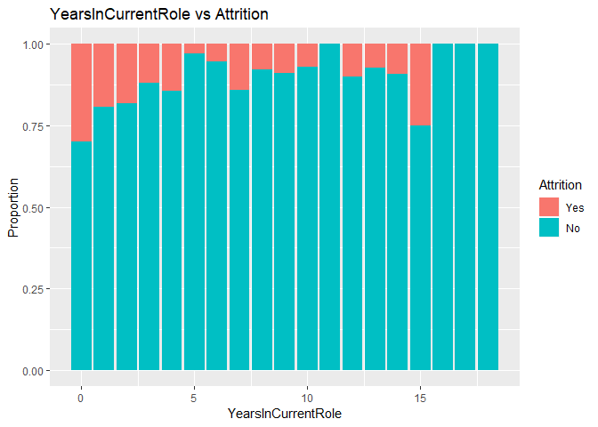

```r
ID="YearsInCurrentRole"
yes=casedata[,sum(Attrition=="Yes"),ID]; colnames(yes)[2]="Yes"
no=casedata[,sum(Attrition=="No"),ID];   colnames(no)[2]="No"
temp=merge(yes,no,all=T)
temp=melt(temp,id=ID)
temp=as.data.frame(temp)
colnames(temp)=c(ID,"Attrition","Count")
temp=merge(temp,as.data.table(temp)[,sum(Count),ID])
colnames(temp)[ncol(temp)]="Total"
temp[["Proportion"]]=temp[["Count"]]/temp[["Total"]]
ggplot(temp,aes(fill=Attrition,y=Proportion,x=eval(as.symbol(ID))))+geom_bar(stat="identity")+xlab(ID)+ggtitle(paste(ID,"vs Attrition"))
```

**The longer a person is in their current role the longer they stay usually.**

```r
temp[temp[["YearsInCurrentRole"]]==15,]
```

```
##    YearsInCurrentRole Attrition Count Total Proportion
## 31                 15        No     6     8       0.75
## 32                 15       Yes     2     8       0.25
```

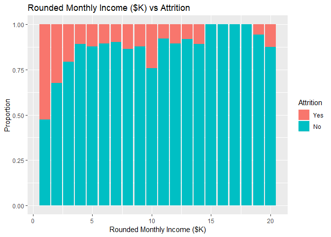

```r
ID="MonthlyIncome2"
casedata[["MonthlyIncome2"]]=round(casedata[["MonthlyIncome"]]/1000)
yes=casedata[,sum(Attrition=="Yes"),ID]; colnames(yes)[2]="Yes"
no=casedata[,sum(Attrition=="No"),ID];   colnames(no)[2]="No"
temp=merge(yes,no,all=T)
temp=melt(temp,id=ID)
temp=as.data.frame(temp)
colnames(temp)=c(ID,"Attrition","Count")
temp=merge(temp,as.data.table(temp)[,sum(Count),ID])
colnames(temp)[ncol(temp)]="Total"
temp[["Proportion"]]=temp[["Count"]]/temp[["Total"]]
ggplot(temp,aes(fill=Attrition,y=Proportion,x=MonthlyIncome2))+geom_bar(stat="identity")+xlab("Rounded Monthly Income ($K)")+ggtitle("Rounded Monthly Income ($K) vs Attrition")
```

**Attrition generally decreases when monthly income increases.**

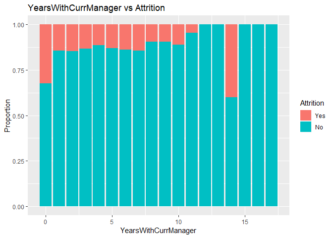

```r
ID="YearsWithCurrManager"
yes=casedata[,sum(Attrition=="Yes"),ID]; colnames(yes)[2]="Yes"
no=casedata[,sum(Attrition=="No"),ID];   colnames(no)[2]="No"
temp=merge(yes,no,all=T)
temp=melt(temp,id=ID)
temp=as.data.frame(temp)
colnames(temp)=c(ID,"Attrition","Count")
temp=merge(temp,as.data.table(temp)[,sum(Count),ID])
colnames(temp)[ncol(temp)]="Total"
temp[["Proportion"]]=temp[["Count"]]/temp[["Total"]]
ggplot(temp,aes(fill=Attrition,y=Proportion,x=eval(as.symbol(ID))))+geom_bar(stat="identity")+xlab(ID)+ggtitle(paste(ID,"vs Attrition"))
```

**The longer your usually with your current manager attrition with an outlier at year 14 where there was only have 5 total observations.**

```r
temp[temp[["YearsWithCurrManager"]]==14,]
```

```
##    YearsWithCurrManager Attrition Count Total Proportion
## 29                   14        No     3     5        0.6
## 30                   14       Yes     2     5        0.4
```

### Worst Indicators

Now let’s take a look at the worst indicators.

```r
tail(pmatrix)
```

```
##             Variable           P-Value
## 1:         Education 0.229315203322316
## 2:       MonthlyRate 0.561123598224303
## 3: PercentSalaryHike 0.605612823889383
## 4:    EmployeeNumber 0.685327589729713
## 5:        HourlyRate 0.793134768994436
## 6: PerformanceRating 0.911884042107093
```

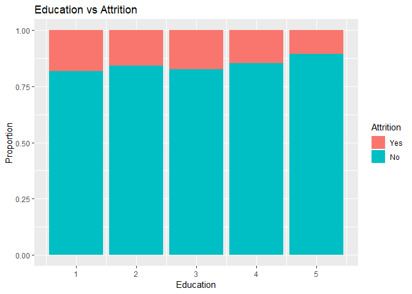

```r
ID="Education"
yes=casedata[,sum(Attrition=="Yes"),ID]; colnames(yes)[2]="Yes"
no=casedata[,sum(Attrition=="No"),ID];   colnames(no)[2]="No"
temp=merge(yes,no,all=T)
temp=melt(temp,id=ID)
temp=as.data.frame(temp)
colnames(temp)=c(ID,"Attrition","Count")
temp=merge(temp,as.data.table(temp)[,sum(Count),ID])
colnames(temp)[ncol(temp)]="Total"
temp[["Proportion"]]=temp[["Count"]]/temp[["Total"]]
ggplot(temp,aes(fill=Attrition,y=Proportion,x=eval(as.symbol(ID))))+geom_bar(stat="identity")+xlab(ID)+ggtitle(paste(ID,"vs Attrition"))
```

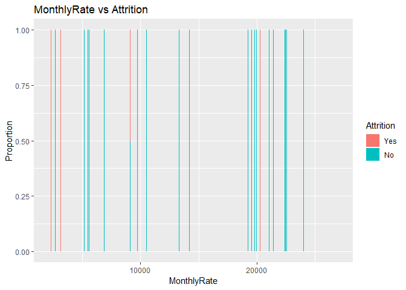

```r
ID="MonthlyRate"
yes=casedata[,sum(Attrition=="Yes"),ID]; colnames(yes)[2]="Yes"
no=casedata[,sum(Attrition=="No"),ID];   colnames(no)[2]="No"
temp=merge(yes,no,all=T)
temp=melt(temp,id=ID)
temp=as.data.frame(temp)
colnames(temp)=c(ID,"Attrition","Count")
temp=merge(temp,as.data.table(temp)[,sum(Count),ID])
colnames(temp)[ncol(temp)]="Total"
temp[["Proportion"]]=temp[["Count"]]/temp[["Total"]]
ggplot(temp,aes(fill=Attrition,y=Proportion,x=eval(as.symbol(ID))))+geom_bar(stat="identity")+xlab(ID)+ggtitle(paste(ID,"vs Attrition"))
```

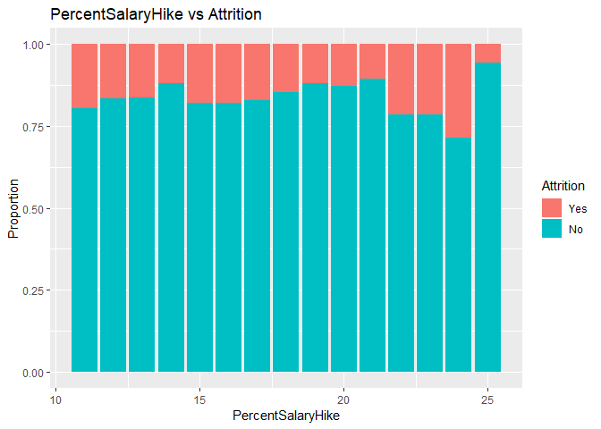

```r
ID="PercentSalaryHike"
yes=casedata[,sum(Attrition=="Yes"),ID]; colnames(yes)[2]="Yes"
no=casedata[,sum(Attrition=="No"),ID];   colnames(no)[2]="No"
temp=merge(yes,no,all=T)
temp=melt(temp,id=ID)
temp=as.data.frame(temp)
colnames(temp)=c(ID,"Attrition","Count")
temp=merge(temp,as.data.table(temp)[,sum(Count),ID])
colnames(temp)[ncol(temp)]="Total"
temp[["Proportion"]]=temp[["Count"]]/temp[["Total"]]
ggplot(temp,aes(fill=Attrition,y=Proportion,x=eval(as.symbol(ID))))+geom_bar(stat="identity")+xlab(ID)+ggtitle(paste(ID,"vs Attrition"))
```

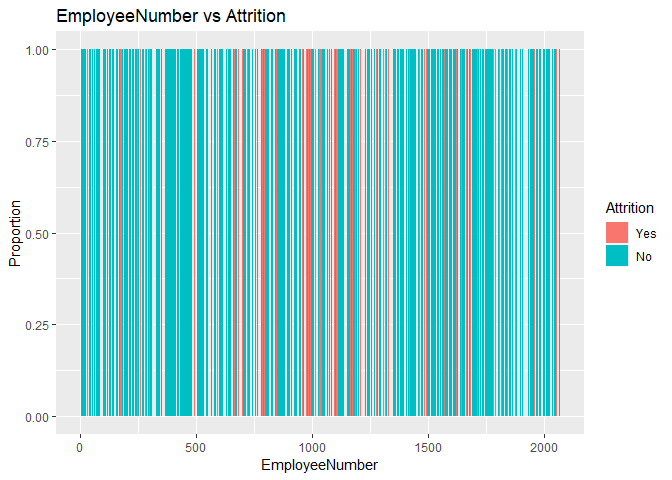

```r
ID="EmployeeNumber"
yes=casedata[,sum(Attrition=="Yes"),ID]; colnames(yes)[2]="Yes"
no=casedata[,sum(Attrition=="No"),ID];   colnames(no)[2]="No"
temp=merge(yes,no,all=T)
temp=melt(temp,id=ID)
temp=as.data.frame(temp)
colnames(temp)=c(ID,"Attrition","Count")
temp=merge(temp,as.data.table(temp)[,sum(Count),ID])
colnames(temp)[ncol(temp)]="Total"
temp[["Proportion"]]=temp[["Count"]]/temp[["Total"]]
ggplot(temp,aes(fill=Attrition,y=Proportion,x=eval(as.symbol(ID))))+geom_bar(stat="identity")+xlab(ID)+ggtitle(paste(ID,"vs Attrition"))
```

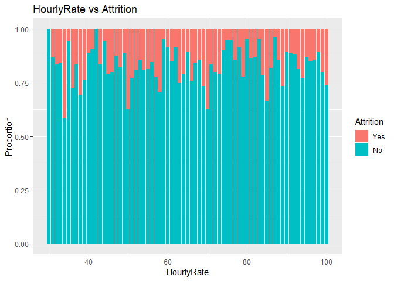

```r
ID="HourlyRate"
yes=casedata[,sum(Attrition=="Yes"),ID]; colnames(yes)[2]="Yes"
no=casedata[,sum(Attrition=="No"),ID];   colnames(no)[2]="No"
temp=merge(yes,no,all=T)
temp=melt(temp,id=ID)
temp=as.data.frame(temp)
colnames(temp)=c(ID,"Attrition","Count")
temp=merge(temp,as.data.table(temp)[,sum(Count),ID])
colnames(temp)[ncol(temp)]="Total"
temp[["Proportion"]]=temp[["Count"]]/temp[["Total"]]
ggplot(temp,aes(fill=Attrition,y=Proportion,x=eval(as.symbol(ID))))+geom_bar(stat="identity")+xlab(ID)+ggtitle(paste(ID,"vs Attrition"))
```

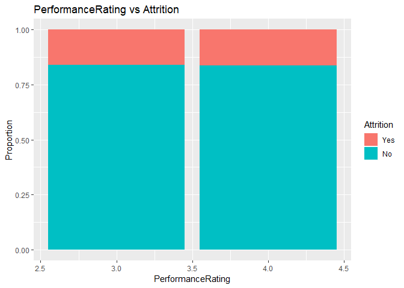

```r
ID="PerformanceRating"
yes=casedata[,sum(Attrition=="Yes"),ID]; colnames(yes)[2]="Yes"
no=casedata[,sum(Attrition=="No"),ID];   colnames(no)[2]="No"
temp=merge(yes,no,all=T)
temp=melt(temp,id=ID)
temp=as.data.frame(temp)
colnames(temp)=c(ID,"Attrition","Count")
temp=merge(temp,as.data.table(temp)[,sum(Count),ID])
colnames(temp)[ncol(temp)]="Total"
temp[["Proportion"]]=temp[["Count"]]/temp[["Total"]]
ggplot(temp,aes(fill=Attrition,y=Proportion,x=eval(as.symbol(ID))))+geom_bar(stat="identity")+xlab(ID)+ggtitle(paste(ID,"vs Attrition"))
```

**There is no significant trends in the worst rated indicators**

```r
temp
```

```
##   PerformanceRating Attrition Count Total Proportion
## 1                 3       Yes   200  1244  0.1607717
## 2                 3        No  1044  1244  0.8392283
## 3                 4       Yes    37   226  0.1637168
## 4                 4        No   189   226  0.8362832
```

### Prep Data for logistic modeling

```r
cns=setdiff(colnames(casedata),"Attrition")
for (cn in cns){
  if (mode(casedata[[cn]])!="numeric"){
    casedata[[cn]]=as.factor(casedata[[cn]])
  }
}
casedata[casedata[["Attrition"]]=="Yes",][["Attrition"]]="1"
casedata[casedata[["Attrition"]]=="No",][["Attrition"]]="0"
mode(casedata[["Attrition"]])="numeric"
```

```r
smp<-floor(0.7*nrow(casedata))
set.seed(1337)
ind <- sample(seq_len(nrow(casedata)),size=smp)
train <- casedata[ind,]
test <- casedata[-ind,]
model <- glm(Attrition ~ ., family = 'binomial', data = train)
summary(model)
```

```
##
## Call:
## glm(formula = Attrition ~ ., family = "binomial", data = train)
##
## Deviance Residuals:
##     Min       1Q   Median       3Q      Max
## -1.6700  -0.4642  -0.2300  -0.0765   3.3223
##
## Coefficients:
##                                    Estimate Std. Error z value Pr(>|z|)
## (Intercept)                      -1.400e+01  6.888e+02  -0.020 0.983786
## Age                              -4.240e-02  1.744e-02  -2.430 0.015078
## BusinessTravelTravel_Frequently   2.407e+00  5.567e-01   4.323 1.54e-05
## BusinessTravelTravel_Rarely       1.323e+00  5.204e-01   2.542 0.011010
## DailyRate                        -2.376e-04  2.726e-04  -0.872 0.383406
## DepartmentResearch & Development  1.406e+01  6.888e+02   0.020 0.983710
## DepartmentSales                   1.297e+01  6.888e+02   0.019 0.984980
## DistanceFromHome                  4.681e-02  1.339e-02   3.497 0.000470
## Education                         4.177e-02  1.089e-01   0.384 0.701280
## EducationFieldLife Sciences      -7.117e-02  1.151e+00  -0.062 0.950688
## EducationFieldMarketing           7.166e-02  1.212e+00   0.059 0.952856
## EducationFieldMedical            -1.788e-01  1.156e+00  -0.155 0.877108
## EducationFieldOther              -7.992e-01  1.230e+00  -0.650 0.515855
## EducationFieldTechnical Degree    5.170e-01  1.188e+00   0.435 0.663282
## EmployeeNumber                   -8.025e-05  1.892e-04  -0.424 0.671496
## EnvironmentSatisfaction          -6.136e-01  1.034e-01  -5.932 2.99e-09
## GenderMale                        3.436e-01  2.293e-01   1.499 0.133945
## HourlyRate                        3.893e-04  5.385e-03   0.072 0.942362
## JobInvolvement                   -5.687e-01  1.582e-01  -3.594 0.000326
## JobLevel                         -1.366e-02  3.819e-01  -0.036 0.971461
## JobRoleHuman Resources            1.660e+01  6.888e+02   0.024 0.980769
## JobRoleLaboratory Technician      2.424e+00  7.400e-01   3.275 0.001055
## JobRoleManager                    1.292e+00  1.079e+00   1.198 0.231065
## JobRoleManufacturing Director     1.001e+00  7.785e-01   1.286 0.198511
## JobRoleResearch Director         -5.823e-01  1.155e+00  -0.504 0.614127
## JobRoleResearch Scientist         1.737e+00  7.523e-01   2.309 0.020921
## JobRoleSales Executive            3.168e+00  1.452e+00   2.181 0.029154
## JobRoleSales Representative       4.308e+00  1.513e+00   2.847 0.004417
## JobSatisfaction                  -3.660e-01  1.015e-01  -3.606 0.000311
## MaritalStatusMarried              1.723e-01  3.149e-01   0.547 0.584267
```

[output cut: 60 more lines]

```
## YearsAtCompany
## YearsInCurrentRole
## YearsSinceLastPromotion          **
## YearsWithCurrManager             .
## MonthlyIncome2
## ---
## Signif. codes:  0 '***' 0.001 '**' 0.01 '*' 0.05 '.' 0.1 ' ' 1
##
## (Dispersion parameter for binomial family taken to be 1)
##
##     Null deviance: 889.30  on 1028  degrees of freedom
## Residual deviance: 567.17  on  982  degrees of freedom
## AIC: 661.17
##
## Number of Fisher Scoring iterations: 15
```

```r
sort(summary(model)$coefficients[,4])
```

```
##                      OverTimeYes          EnvironmentSatisfaction
##                     6.020049e-17                     2.987575e-09
##               NumCompaniesWorked  BusinessTravelTravel_Frequently
##                     4.704626e-06                     1.538695e-05
##                  JobSatisfaction                   JobInvolvement
##                     3.108828e-04                     3.259730e-04
##                 DistanceFromHome     JobRoleLaboratory Technician
##                     4.696854e-04                     1.055045e-03
##          YearsSinceLastPromotion      JobRoleSales Representative
##                     1.904508e-03                     4.417167e-03
##                  WorkLifeBalance              MaritalStatusSingle
##                     5.315988e-03                     1.027557e-02
##      BusinessTravelTravel_Rarely                              Age
##                     1.100990e-02                     1.507809e-02
##            TrainingTimesLastYear        JobRoleResearch Scientist
##                     1.711564e-02                     2.092100e-02
##                TotalWorkingYears           JobRoleSales Executive
##                     2.793769e-02                     2.915360e-02
##         RelationshipSatisfaction             YearsWithCurrManager
##                     2.935008e-02                     5.706970e-02
##               YearsInCurrentRole                       GenderMale
##                     1.148842e-01                     1.339454e-01
##                PercentSalaryHike    JobRoleManufacturing Director
##                     1.379117e-01                     1.985108e-01
##                   JobRoleManager                PerformanceRating
##                     2.310651e-01                     2.435390e-01
##                   YearsAtCompany                    MonthlyIncome
##                     3.217849e-01                     3.664730e-01
##                        DailyRate                   MonthlyIncome2
##                     3.834058e-01                     4.673636e-01
##              EducationFieldOther                      MonthlyRate
##                     5.158552e-01                     5.210519e-01
##                 StockOptionLevel             MaritalStatusMarried
##                     5.360777e-01                     5.842668e-01
##         JobRoleResearch Director   EducationFieldTechnical Degree
##                     6.141268e-01                     6.632818e-01
##                   EmployeeNumber                        Education
##                     6.714958e-01                     7.012805e-01
##            EducationFieldMedical                       HourlyRate
##                     8.771082e-01                     9.423620e-01
##      EducationFieldLife Sciences          EducationFieldMarketing
##                     9.506883e-01                     9.528562e-01
##                         JobLevel           JobRoleHuman Resources
##                     9.714610e-01                     9.807688e-01
## DepartmentResearch & Development                      (Intercept)
##                     9.837100e-01                     9.837865e-01
##                  DepartmentSales
##                     9.849799e-01
```

### Select Statistically Significant Variables

alpha = 0.05

```r
coefs=summary(model)$coefficients
temp=coefs[coefs[,4]<0.05,]
temp[,4][order(temp[,4])]
```

```
##                     OverTimeYes         EnvironmentSatisfaction
##                    6.020049e-17                    2.987575e-09
##              NumCompaniesWorked BusinessTravelTravel_Frequently
##                    4.704626e-06                    1.538695e-05
##                 JobSatisfaction                  JobInvolvement
##                    3.108828e-04                    3.259730e-04
##                DistanceFromHome    JobRoleLaboratory Technician
##                    4.696854e-04                    1.055045e-03
##         YearsSinceLastPromotion     JobRoleSales Representative
##                    1.904508e-03                    4.417167e-03
##                 WorkLifeBalance             MaritalStatusSingle
##                    5.315988e-03                    1.027557e-02
##     BusinessTravelTravel_Rarely                             Age
##                    1.100990e-02                    1.507809e-02
##           TrainingTimesLastYear       JobRoleResearch Scientist
##                    1.711564e-02                    2.092100e-02
##               TotalWorkingYears          JobRoleSales Executive
##                    2.793769e-02                    2.915360e-02
##        RelationshipSatisfaction
##                    2.935008e-02
```

```r
variables=names(temp[,4][order(temp[,4])])
variables
```

```
##  [1] "OverTimeYes"                     "EnvironmentSatisfaction"
##  [3] "NumCompaniesWorked"              "BusinessTravelTravel_Frequently"
##  [5] "JobSatisfaction"                 "JobInvolvement"
##  [7] "DistanceFromHome"                "JobRoleLaboratory Technician"
##  [9] "YearsSinceLastPromotion"         "JobRoleSales Representative"
## [11] "WorkLifeBalance"                 "MaritalStatusSingle"
## [13] "BusinessTravelTravel_Rarely"     "Age"
## [15] "TrainingTimesLastYear"           "JobRoleResearch Scientist"
## [17] "TotalWorkingYears"               "JobRoleSales Executive"
## [19] "RelationshipSatisfaction"
```

```r
formula_vars=c()
for (var in variables){
  if (var %in% colnames(casedata)){
    formula_vars=c(formula_vars,var)
  } else {
    letters=strsplit(var,"")[[1]]
    word=c()
    for (letter in letters){
      word=paste0(word,letter,sep="")
      if (word %in% colnames(casedata)){
        formula_vars=c(formula_vars,word)
      }
    }
  }
}
formula_vars=unique(formula_vars)
formula=paste0(paste0(formula_vars,sep="+"),collapse="")
formula=paste0(strsplit(formula,"")[[1]][1:(length(strsplit(formula,"")[[1]])-1)],collapse = "")
formula=paste0("Attrition~",formula,collapse="")
formula
```

[output not shown]

```r
glm(formula,family = 'binomial', data = train)
```

```
##
## Call:  glm(formula = formula, family = "binomial", data = train)
##
## Coefficients:
##                     (Intercept)                      OverTimeYes
##                         0.83745                          1.99343
##         EnvironmentSatisfaction               NumCompaniesWorked
##                        -0.60240                          0.23236
## BusinessTravelTravel_Frequently      BusinessTravelTravel_Rarely
##                         2.56362                          1.49671
##                 JobSatisfaction                   JobInvolvement
##                        -0.37784                         -0.60576
##                DistanceFromHome           JobRoleHuman Resources
##                         0.04455                          2.34108
##    JobRoleLaboratory Technician                   JobRoleManager
##                         2.13240                          1.63850
##   JobRoleManufacturing Director         JobRoleResearch Director
##                         0.90060                          0.26489
##       JobRoleResearch Scientist           JobRoleSales Executive
##                         1.42650                          2.05567
##     JobRoleSales Representative          YearsSinceLastPromotion
##                         2.95468                          0.14486
##                 WorkLifeBalance             MaritalStatusMarried
##                        -0.45345                          0.18374
##             MaritalStatusSingle                              Age
##                         1.21383                         -0.03718
##           TrainingTimesLastYear                TotalWorkingYears
##                        -0.22048                         -0.08789
##        RelationshipSatisfaction
##                        -0.19261
##
## Degrees of Freedom: 1028 Total (i.e. Null);  1004 Residual
## Null Deviance:       889.3
## Residual Deviance: 592.2     AIC: 642.2
```

### Run New Linear Model

```r
newmodel <- glm(formula, family = 'binomial', data = train)
pander(newmodel)
```

Fitting generalized (binomial/logit) linear model: formula

|  | Estimate | Std. Error | z value | Pr(>\|z\|) |
| --- | --- | --- | --- | --- |
| **(Intercept)** | 0.8375 | 1.219 | 0.6868 | 0.4922 |
| **OverTimeYes** | 1.993 | 0.2347 | 8.495 | 1.983e-17 |
| **EnvironmentSatisfaction** | -0.6024 | 0.09936 | -6.063 | 1.34e-09 |
| **NumCompaniesWorked** | 0.2324 | 0.04451 | 5.22 | 1.789e-07 |
| **BusinessTravelTravel_Frequently** | 2.564 | 0.5457 | 4.698 | 2.629e-06 |
| **BusinessTravelTravel_Rarely** | 1.497 | 0.5089 | 2.941 | 0.003273 |
| **JobSatisfaction** | -0.3778 | 0.09701 | -3.895 | 9.819e-05 |
| **JobInvolvement** | -0.6058 | 0.1516 | -3.995 | 6.46e-05 |
| **DistanceFromHome** | 0.04455 | 0.01274 | 3.497 | 0.0004703 |
| **JobRoleHuman Resources** | 2.341 | 0.8442 | 2.773 | 0.005552 |
| **JobRoleLaboratory Technician** | 2.132 | 0.6797 | 3.137 | 0.001705 |
| **JobRoleManager** | 1.639 | 0.8599 | 1.905 | 0.05673 |
| **JobRoleManufacturing Director** | 0.9006 | 0.764 | 1.179 | 0.2385 |
| **JobRoleResearch Director** | 0.2649 | 1.016 | 0.2607 | 0.7943 |
| **JobRoleResearch Scientist** | 1.426 | 0.6855 | 2.081 | 0.03743 |
| **JobRoleSales Executive** | 2.056 | 0.6669 | 3.083 | 0.002053 |
| **JobRoleSales Representative** | 2.955 | 0.7346 | 4.022 | 5.771e-05 |
| **YearsSinceLastPromotion** | 0.1449 | 0.04291 | 3.376 | 0.0007358 |
| **WorkLifeBalance** | -0.4535 | 0.1505 | -3.012 | 0.002594 |
| **MaritalStatusMarried** | 0.1837 | 0.3005 | 0.6115 | 0.5409 |
| **MaritalStatusSingle** | 1.214 | 0.3079 | 3.942 | 8.077e-05 |
| **Age** | -0.03718 | 0.01637 | -2.272 | 0.02309 |
| **TrainingTimesLastYear** | -0.2205 | 0.09201 | -2.396 | 0.01657 |
| **TotalWorkingYears** | -0.08789 | 0.02772 | -3.171 | 0.00152 |
| **RelationshipSatisfaction** | -0.1926 | 0.09882 | -1.949 | 0.05127 |

```r
sort(summary(newmodel)$coefficients[,4])
```

```
##                     OverTimeYes         EnvironmentSatisfaction
##                    1.982890e-17                    1.339629e-09
##              NumCompaniesWorked BusinessTravelTravel_Frequently
##                    1.788985e-07                    2.628938e-06
##     JobRoleSales Representative                  JobInvolvement
##                    5.770751e-05                    6.459506e-05
##             MaritalStatusSingle                 JobSatisfaction
##                    8.076814e-05                    9.818905e-05
##                DistanceFromHome         YearsSinceLastPromotion
##                    4.703270e-04                    7.358070e-04
##               TotalWorkingYears    JobRoleLaboratory Technician
##                    1.519567e-03                    1.704769e-03
##          JobRoleSales Executive                 WorkLifeBalance
##                    2.052676e-03                    2.593861e-03
##     BusinessTravelTravel_Rarely          JobRoleHuman Resources
##                    3.273422e-03                    5.552400e-03
##           TrainingTimesLastYear                             Age
##                    1.656713e-02                    2.308832e-02
##       JobRoleResearch Scientist        RelationshipSatisfaction
##                    3.743095e-02                    5.127044e-02
##                  JobRoleManager   JobRoleManufacturing Director
##                    5.673055e-02                    2.384682e-01
##                     (Intercept)            MaritalStatusMarried
##                    4.922274e-01                    5.408844e-01
##        JobRoleResearch Director
##                    7.942885e-01
```

### Model Evaluation: Training Data Set

```r
predmodel=round(predict(newmodel,train,type='response'),digits=0)
modelcomparison= as.data.table(cbind(predmodel,train$Attrition,train$EmployeeNumber))
colnames(modelcomparison)=c("Predicted","Actual","EmployeeNumber")
modelcomparison
```

```
##       Predicted Actual EmployeeNumber
##    1:         0      0           1184
##    2:         1      1           1157
##    3:         0      0            143
##    4:         1      0            925
##    5:         0      1            752
##   ---
## 1025:         0      0             10
## 1026:         0      0           1881
## 1027:         1      1           1752
## 1028:         0      0           1399
## 1029:         0      1            825
```

```r
TN=nrow(modelcomparison[modelcomparison[["Predicted"]]==0 & modelcomparison[["Actual"]]==0,])
FN=nrow(modelcomparison[modelcomparison[["Predicted"]]==0 & modelcomparison[["Actual"]]==1,])
TP=nrow(modelcomparison[modelcomparison[["Predicted"]]==1 & modelcomparison[["Actual"]]==1,])
FP=nrow(modelcomparison[modelcomparison[["Predicted"]]==1 & modelcomparison[["Actual"]]==0,])
mat=matrix(ncol=2,nrow=2)
mat[1,1]=TN
mat[1,2]=FP
mat[2,1]=FN
mat[2,2]=TP
colnames(mat)=c("Predicted=0","Predicted=1")
rownames(mat)=c("Actual=0","Actual=1")
print(nrow(train)==sum(mat))
```

```
## [1] TRUE
```

```r
TrainResults=mat
TrainResults
```

```
##          Predicted=0 Predicted=1
## Actual=0         847          22
## Actual=1          86          74
```

```r
mat=mat/sum(mat)
RelTrainResults=mat
RelTrainResults
```

```
##          Predicted=0 Predicted=1
## Actual=0  0.82312925  0.02137998
## Actual=1  0.08357629  0.07191448
```

```r
cat("Total Training Dataset Accuracy: ",(TP+TN)/sum(TrainResults))
```

```
## Total Training Dataset Accuracy:  0.8950437
```

### Model Evaluation: Test Data Set

```r
predmodel=round(predict(newmodel,test,type='response'),digits=0)
modelcomparison= as.data.table(cbind(predmodel,test$Attrition,test$EmployeeNumber))
colnames(modelcomparison)=c("Predicted","Actual","EmployeeNumber")
modelcomparison
```

```
##      Predicted Actual EmployeeNumber
##   1:         0      0              2
##   2:         1      1              4
##   3:         0      0              8
##   4:         0      0             18
##   5:         0      0             22
##  ---
## 437:         0      1           2032
## 438:         0      0           2034
## 439:         0      0           2049
## 440:         0      0           2065
## 441:         0      0           2068
```

```r
TN=nrow(modelcomparison[modelcomparison[["Predicted"]]==0 & modelcomparison[["Actual"]]==0,])
FN=nrow(modelcomparison[modelcomparison[["Predicted"]]==0 & modelcomparison[["Actual"]]==1,])
TP=nrow(modelcomparison[modelcomparison[["Predicted"]]==1 & modelcomparison[["Actual"]]==1,])
FP=nrow(modelcomparison[modelcomparison[["Predicted"]]==1 & modelcomparison[["Actual"]]==0,])
mat=matrix(ncol=2,nrow=2)
mat[1,1]=TN
mat[1,2]=FP
mat[2,1]=FN
mat[2,2]=TP
colnames(mat)=c("Predicted=0","Predicted=1")
rownames(mat)=c("Actual=0","Actual=1")
print(nrow(test)==sum(mat))
```

```
## [1] TRUE
```

```r
TestResults=mat
TestResults
```

```
##          Predicted=0 Predicted=1
## Actual=0         354          10
## Actual=1          42          35
```

```r
mat=mat/sum(mat)
RelTestResults=mat
RelTestResults
```

```
##          Predicted=0 Predicted=1
## Actual=0   0.8027211  0.02267574
## Actual=1   0.0952381  0.07936508
```

```r
cat("Total Test Dataset Accuracy: ",(TP+TN)/sum(TestResults))
```

```
## Total Test Dataset Accuracy:  0.8820862
```

### Forward Variable Selection

```r
vars=colnames(casedata)
rm(model)
formula="Attrition~"
for (var in vars){
  #print(var)
  if (exists('model')){
    new_formula=paste0(formula,"+",var)
    new_model=glm(new_formula,family="binomial",data=train)
    predmodel=round(predict(new_model,train,type='response'),digits=0)
    modelcomparison= as.data.table(cbind(predmodel,train$Attrition,train$EmployeeNumber))
    colnames(modelcomparison)=c("Predicted","Actual","EmployeeNumber")
    x1=sum(modelcomparison[["Predicted"]]==modelcomparison[["Actual"]])
    predmodel2=round(predict(model,train,type='response'),digits=0)
    modelcomparison2= as.data.table(cbind(predmodel2,train$Attrition,train$EmployeeNumber))
    colnames(modelcomparison2)=c("Predicted","Actual","EmployeeNumber")
    x2=sum(modelcomparison2[["Predicted"]]==modelcomparison2[["Actual"]])
    if (x1>x2){
      formula=new_formula
      model=new_model
      # print(formula)
      # print(x1)
    }
  } else {
    formula=paste0(formula,"+",var)
    model=glm(formula, family = 'binomial', data = train)
  }
}
coefs=summary(model)$coefficients
temp=coefs[coefs[,4]<0.05,]
temp[,4][order(temp[,4])]
```

```
##             OverTimeYes YearsSinceLastPromotion      YearsInCurrentRole
##            7.257804e-14            1.310047e-03            6.613961e-03
##                     Age
##            2.245040e-02
```

```r
    predmodel=round(predict(model,test,type='response'),digits=0)
    modelcomparison= as.data.table(cbind(predmodel,test$Attrition,test$EmployeeNumber))
    colnames(modelcomparison)=c("Predicted","Actual","EmployeeNumber")
    sum(modelcomparison[["Predicted"]]==modelcomparison[["Actual"]])/nrow(test)
```

```
## [1] 0.829932
```

```r
TN=nrow(modelcomparison[modelcomparison[["Predicted"]]==0 & modelcomparison[["Actual"]]==0,])
FN=nrow(modelcomparison[modelcomparison[["Predicted"]]==0 & modelcomparison[["Actual"]]==1,])
TP=nrow(modelcomparison[modelcomparison[["Predicted"]]==1 & modelcomparison[["Actual"]]==1,])
FP=nrow(modelcomparison[modelcomparison[["Predicted"]]==1 & modelcomparison[["Actual"]]==0,])
mat=matrix(ncol=2,nrow=2)
mat[1,1]=TN
mat[1,2]=FP
mat[2,1]=FN
mat[2,2]=TP
colnames(mat)=c("Predicted=0","Predicted=1")
rownames(mat)=c("Actual=0","Actual=1")
print(nrow(test)==sum(mat))
```

```
## [1] TRUE
```

```r
mat
```

```
##          Predicted=0 Predicted=1
## Actual=0         361           3
## Actual=1          72           5
```

```r
mat/sum(mat)
```

```
##          Predicted=0 Predicted=1
## Actual=0   0.8185941 0.006802721
## Actual=1   0.1632653 0.011337868
```

```r
cat("Total Test Dataset Accuracy: ",(TP+TN)/sum(mat))
```

```
## Total Test Dataset Accuracy:  0.829932
```

```r
pander(model)
```

Fitting generalized (binomial/logit) linear model: new_formula

|  | Estimate | Std. Error | z value | Pr(>\|z\|) |
| --- | --- | --- | --- | --- |
| **(Intercept)** | 0.01218 | 0.9501 | 0.01282 | 0.9898 |
| **Age** | -0.03379 | 0.0148 | -2.283 | 0.02245 |
| **OverTimeYes** | 1.398 | 0.1868 | 7.483 | 7.258e-14 |
| **PerformanceRating** | 0.02871 | 0.2567 | 0.1119 | 0.9109 |
| **RelationshipSatisfaction** | -0.1541 | 0.08567 | -1.799 | 0.07207 |
| **TotalWorkingYears** | -0.04012 | 0.02329 | -1.723 | 0.08487 |
| **YearsAtCompany** | -0.02281 | 0.03486 | -0.6543 | 0.5129 |
| **YearsInCurrentRole** | -0.123 | 0.04528 | -2.716 | 0.006614 |
| **YearsSinceLastPromotion** | 0.1402 | 0.04364 | 3.214 | 0.00131 |

```r
coefs=summary(model)$coefficients
temp=coefs[coefs[,4]<0.05,]
temp[,4][order(temp[,4])]
```

```
##             OverTimeYes YearsSinceLastPromotion      YearsInCurrentRole
##            7.257804e-14            1.310047e-03            6.613961e-03
##                     Age
##            2.245040e-02
```

### Data Analysis & Conclusion

After cleaning the data file. It was determined the following variables were the top single variable parameters that correspond to attrition:

1: TotalWorkingYears

2: JobLevel

3: YearsInCurrentRole

Based on a logistic model on certain variables, with statistical significance of <5%, of a full model here are the top three parameters that correspond to attrition:

1: OverTime

2: EnvironmentSatisfaction

3: NumCompaniesWorked

The logistic model also generated a **88% accuracy** on the test dataset.

Based on a forward selection model, here are the top three parameters that correspond to attrition:

1: OverTimeYes

2: YearsSinceLastPromotion

3: YearsInCurrentRole

The forward variable selection model also generated a **83% accuracy** on the test dataset.